## Making a package

Alternatively, we can make a package that you re-load (this is called building and reloading)

Go to Tools, Project Options, Build Tools and write in in the directory of the package you created (check dev.tools and roxygen)

Then in Build (on Rstudio options) Load all and when you make changes Build and Reload

When you start Rstudio with your project; after having closed your session go to Build; load all This will add everything

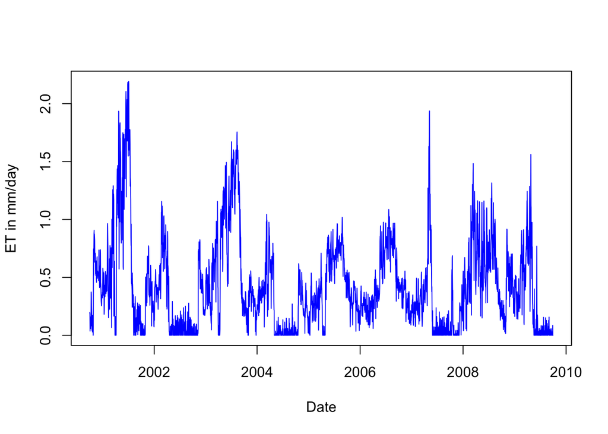

```r
data(metdata)
etres=with(metdata,penman_montieth(Tair=tavg, vpd=vpd, Rnet=rnet, gs=gs, ga=ga, dayl=24))
metdata$et = etres

plot(metdata$date, metdata$et, type="l", col="blue",
     ylab="ET in mm/day", xlab="Date")
```

# adding more to your package

Create your .R file with proper documentation format and then add it to the ecohydrotools/R directory

Lets try with compute_yield.R, if its in that directory document will automoatically find it

```r
setwd("/Users/naomi/UCSB.GoogleDrive/courses/Israel/Recohydro/ecohydrotools")
document()
```

```
## Updating ecohydrotools documentation
```

```
## Loading ecohydrotools
```

```r
help(compute_yield)
```

```
## Using development documentation for compute_yield
```

```r
compute_yield(T=20, P=250, irr=200, base.yield=500, Topt=25, max.water=800)
```

```
## $yield
## [1] 723
##
## $yield.no.irrigation
## [1] 623
```

```r
# to see code
compute_yield
```

```
## function(T, P, irr, max.water, Topt, base.yield, Tslope=0.4, Pslope=0.5) {
##
##
##
## nyears=length(T)
##
## # compute with irrigation
## irr.peryear = rep(irr, times=nyears)
## water.input = P+irr.peryear;
## yield = ifelse(water.input < max.water,
##  Pslope*water.input - Tslope*abs(T-Topt) + base.yield,
##  Pslope*max.water - Tslope*abs(T-Topt) + base.yield )
## yield=pmax(yield,0)
##
## #now computed without irrigation
## water.input = P;
## yield.noirr = ifelse(water.input < max.water,
##                Pslope*water.input - Tslope*abs(T-Topt) + base.yield,
##                Pslope*max.water - Tslope*abs(T-Topt) + base.yield )
## yieldnoirr=pmax(yield.noirr,0)
##
##
## return(list(yield=yield, yield.no.irrigation=yieldnoirr))
##
##
## }
## <environment: namespace:ecohydrotools>
```

```r
# lets see an example over multiple years
# play with our metdata

data(metdata)
library(dplyr)
# create a new table that summarizes by wateryear, use mean for state variables, and sum for flux variables
# this uses functions from the dplyr package
a = metdata %>% select(wy, tavg) %>% group_by(wy) %>%
    summarize_each(funs(mean))

b = metdata %>% select(wy,precip) %>% group_by(wy) %>%
    summarize_each(funs(sum))

# link data sets together (automatically uses shared colums)
clim.wy = inner_join(a,b)
head(clim.wy)
```

```
## # A tibble: 6 x 3
##      wy     tavg   precip
##   <int>    <dbl>    <dbl>
## 1  2001 15.61369  803.570
## 2  2002 15.61147  190.164
## 3  2003 16.27891  492.614
## 4  2004 16.19803  303.022
## 5  2005 15.91196 1181.100
## 6  2006 16.35139  643.890
```

```r
# now apply
res = compute_yield(T=clim.wy$tavg, P=clim.wy$precip, irr=200, base.yield=500, Topt=25, max.water=800)
head(res)
```

```
## $yield
## [1] 896.2455 691.3266 842.8186 747.9902 896.3648 896.5406 701.0839 875.3260
## [9] 761.2274
##
## $yield.no.irrigation
## [1] 896.2455 591.3266 742.8186 647.9902 896.3648 818.4856 601.0839 775.3260
## [9] 661.2274
```

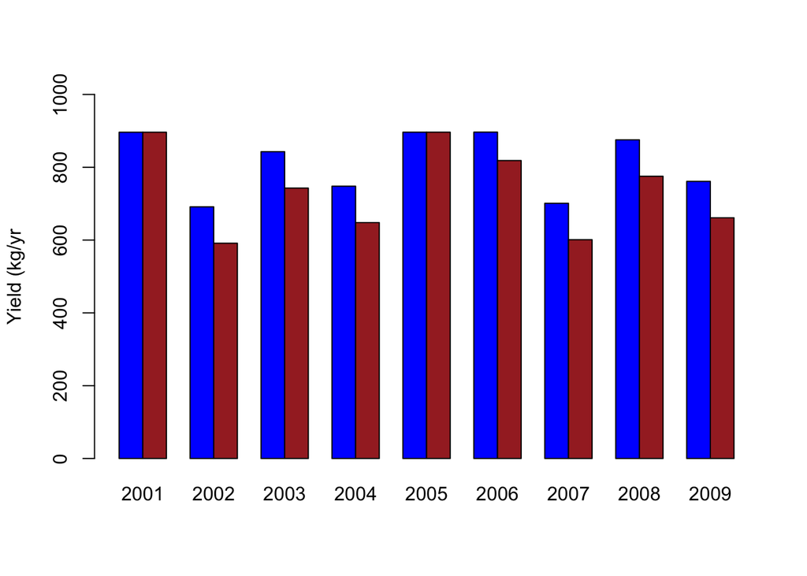

```r
barplot(rbind(res$yield, res$yield.no.irrigation), beside=T, ylab="Yield (kg/yr", names=clim.wy$wy, col=c("blue","brown"), ylim=c(0,1000))
legend("bottom", legend=c("Irrigation","No Irrigation"), col=c("blue","red"), pch=15, horiz=TRUE, bty="n", xpd=TRUE, inset=c(0,-1))
```

**Remember to add and commit these changes to you local git and when you are ready push to github**